# Assignment 1 - The tidyverse

Giulia Maria Petrilli + GiuliaGGG

October 10, 2023 | 19:08:33 | CEST

```r
library(legislatoR)
library(tidyverse)
library(ggplot2)
```

### Getting started with the Comparative Legislators Database

The Comparative Legislators Database (CLD) includes political, sociodemographic, career, online presence, public attention, and visual information for over 45,000 contemporary and historical politicians from ten countries (see the [corresponding article](https://www.cambridge.org/core/journals/british-journal-of-political-science/article/comparative-legislators-database/D28BB58A8B2C08C8593DB741F42C18B2) for more information). It can be accessed via `legislatoR` - an R package that is available on both [CRAN](https://cran.r-project.org/web/packages/legislatoR/index.html) and [GitHub](https://github.com/saschagobel/legislatoR).

Before you start with the following tasks, skim the tutorial to make yourself familiar with the database. You find it [here](https://cran.r-project.org/web/packages/legislatoR/vignettes/legislatoR.html).

For the following tasks, you will work with ONE of the legislatures. The legislature you’ll work with depends on your first name:

| Your first name starts with… | Legislature | Code |
| --- | --- | --- |
| A-C | Austrian Nationalrat | `aut` |
| D-F | Canadian House of Commons | `can` |
| G-I | Czech Poslanecka Snemovna | `cze` |
| J-L | Spanish Congreso de los Diputados | `esp` |
| M-O | French Assemblée | `fra` |
| P-R | German Bundestag | `deu` |
| S-U | Irish Dail | `irl` |
| V-X | UK House of Commons | `gbr` |
| Y-Z | US House of Representatives | `usa_house` |

The following tasks will be based on data from the `core` and `political` tables of the database.

### Task 1 - Descriptives

1. What’s the overall share of female legislators in the entire dataset?

```r
# Creating the datasets
core  <- get_core(legislature = "cze")
political <- get_political(legislature = "cze")

# Add a column with binary sex values to the dataset, Male = 0, Female = 1
core_binary_gender <- core |>
  mutate(binary_gender = ifelse(sex == "female", 1, 0)) |>
  drop_na(sex)

# Calculate and Print the mean of the binary column
# Multiply by 100 for share
female_legislators_share <- print(mean(core_binary_gender$binary_gender)*100)
```

```
[1] 19.50134
```

2. How many (both in absolute and relative terms) legislators died in the same place they were born in?

```r
# Select and Clean the columns of interest
# Filter matching results between birth and death places
same_birth_death_places <- drop_na(select(core, birthplace, deathplace)) |>
  filter(birthplace == deathplace)
count(same_birth_death_places) # Absolute value
```

| n |
| --- |
| 6 |

```r
# Relative value
# nr. of birthplace = deathplace/ #nr. of known deathplaces that also have a known birthplace
birth_death_places <- drop_na(select(core, birthplace, deathplace))
count(same_birth_death_places)/count(birth_death_places)
```

| n |
| --- |
| 0.4 |

The analysis takes as denominator the people that have available birthplace and deathplace. Deathplaces that have no birthplace are irrelevant because the person couldhave been born in the same place they died in but that information is not available. Hence, taking that information into account might lead ot an imprecise analysis. Additionally, not all legislators are taken as denominator because not all of them died and the analysis investigates the deathplace variable.

3. Create a new variable `age_at_death` that reports the age at which legislators died. Then, plot the distribution of that variable for the entire dataset.

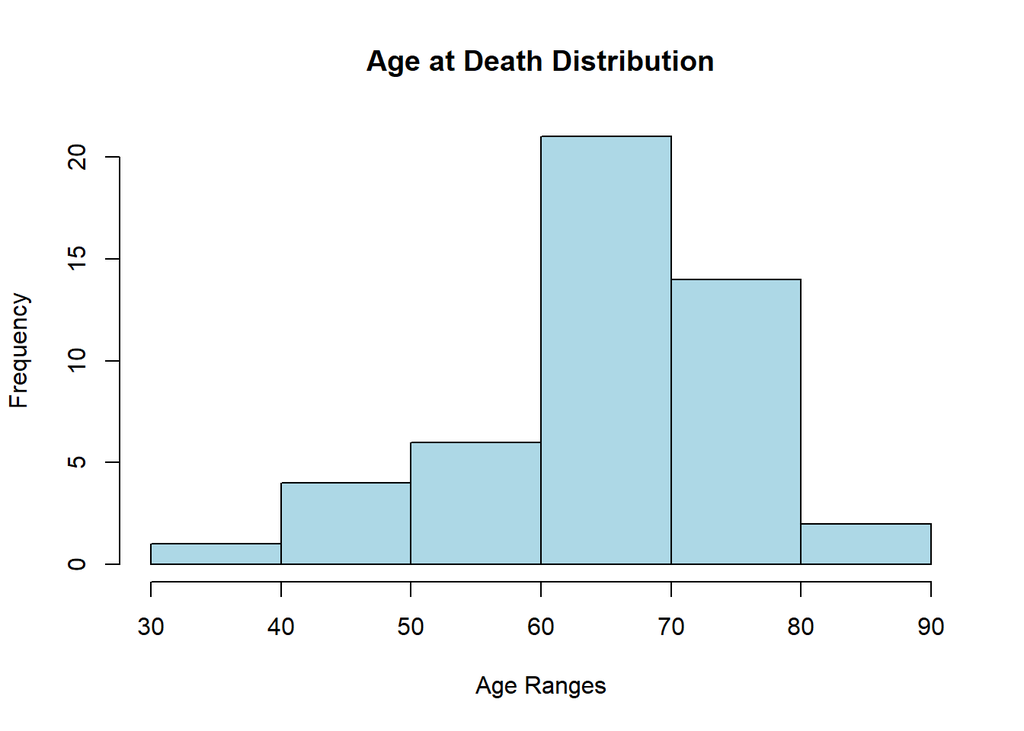

```r
# Select and Clean the columns of interest
# Use mutate() to add age_at_death
birth_death_dates <-  drop_na(select(core, birth, death))|>
  mutate(age_at_death = (as.numeric(difftime(death, birth, units = "days")) / 365)) |>
  drop_na()

# Show the variable distribution
hist(
  birth_death_dates$age_at_death, col = "lightblue",
  main = "Age at Death Distribution",
  ylab = "Frequency",
  xlab = "Age Ranges")
```

4. What is the most frequent birthday in your sample (e.g., “January 15”)?

```r
most_frequent_birthday <-
  core |>
  mutate(birth = format(as.Date(birth), "%B %d, %Y"),
          # Change the format as in the task description above - Month Day
         birth = sub(", \\d{4}$", "", birth)) |>
         # Remove year to prevent the selection of birthdates
  count(birth, sort = TRUE) |>
  slice(1)
most_frequent_birthday # Print
```

| birth | n |
| --- | --- |
| January 01 | 13 |

5. Generate a table that provides the 5 legislators with the longest names (in terms of number of characters, ignoring whitespace).

```r
longest_names <-
  core |>
  mutate(name_no_space = gsub(" ", "", name), # Add name variable without spaces to core
         char_count = nchar(name_no_space)) |> # Add column with character count
  arrange(-char_count) |> # Slice the ordered 5 top names based on character count
  select(name) |>
  slice_head(n = 5) # Slice the 5 longest names
longest_names # Print
```

| name |
| --- |
| Zuzana Majerová Zahradníková |
| Jaroslava Pokorná Jermanová |
| Augustin Karel Andrle Sylor |
| Jana Mračková Vildumetzová |
| Zdenka Němečková Crkvenjaš |

### Task 2 - Exploring trends in the data

1. Using data from all sessions, provide a plot that shows the share of female legislators by session!

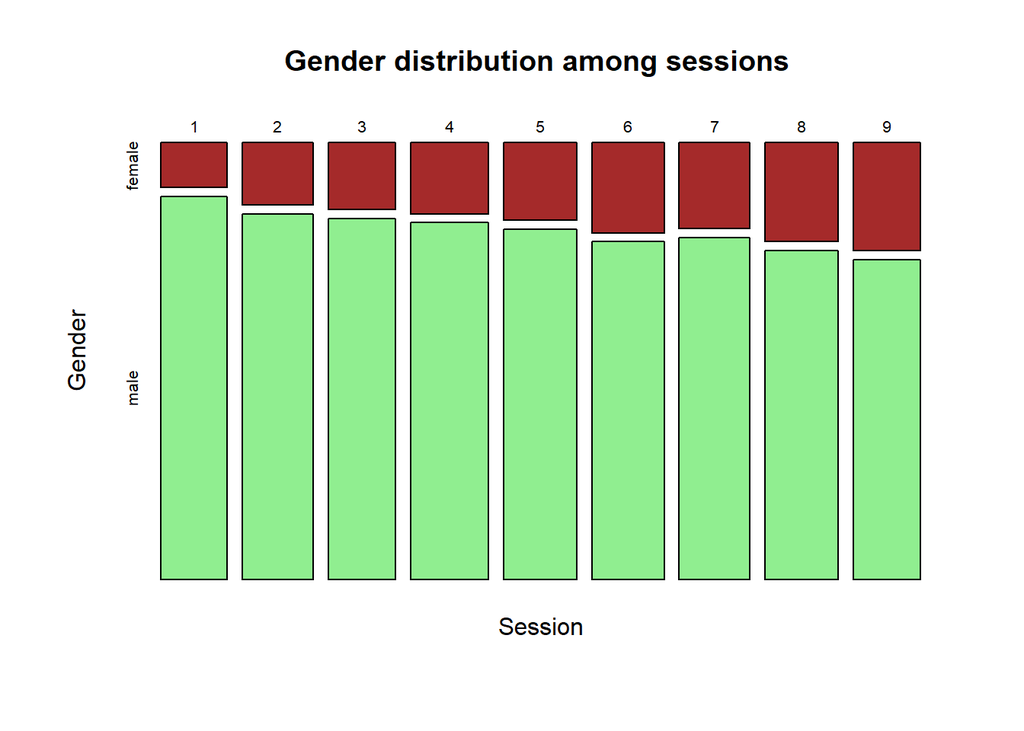

```r
# Joint the two datasets by the common column pageid

joint_df <- left_join(
  core,
  political,
  by = join_by(pageid))

plot(
  table(
    joint_df$session, joint_df$sex),
  main = "Gender distribution among sessions ",
  xlab = "Session",
  ylab = "Gender",
     col = c("brown", "lightgreen"))
```

This plot is coherent with the trend of increasing women in politics over the years. The next analysis will focus on the gender ratio across different parties, and how that changes with time.

2. Explore another relation of variables in the dataset. Your analysis should (i) use data from both the `core` and the `political` table and (ii) feature data from several sessions. Also, offer a brief description and interpretation of your findings!

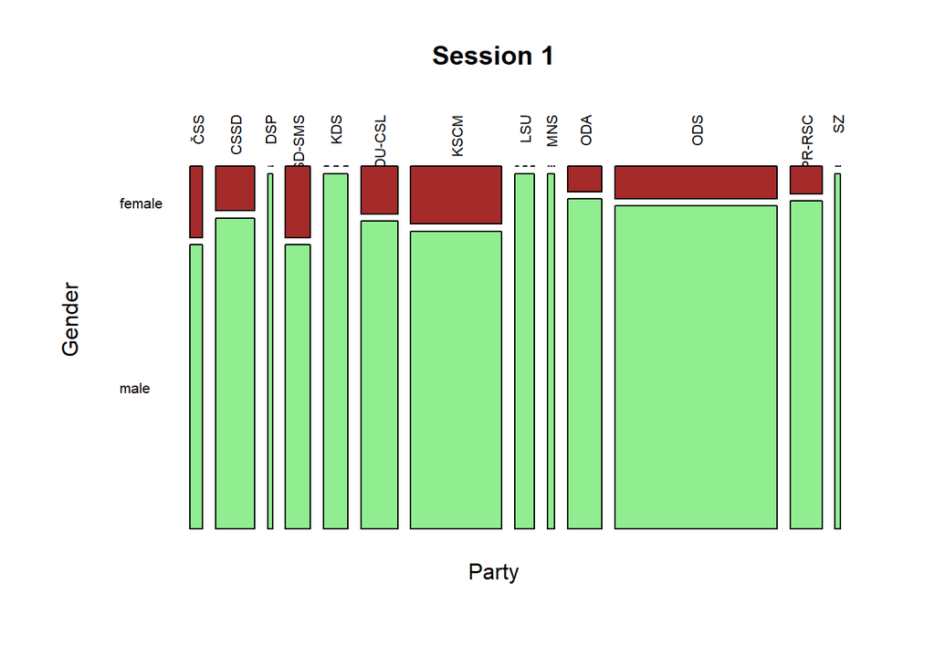

```r
# Gender and parties
# Isolate session 1
session_1 <- joint_df |>
  filter(session < 2)

# Plot party and sex with rotated x-axis labels for readability
plot(
  table(
    session_1$party, session_1$sex),
  main = "Session 1",
  xlab = "Party",
  ylab = "Gender",
     col = c("brown", "lightgreen"), las = 2)
```

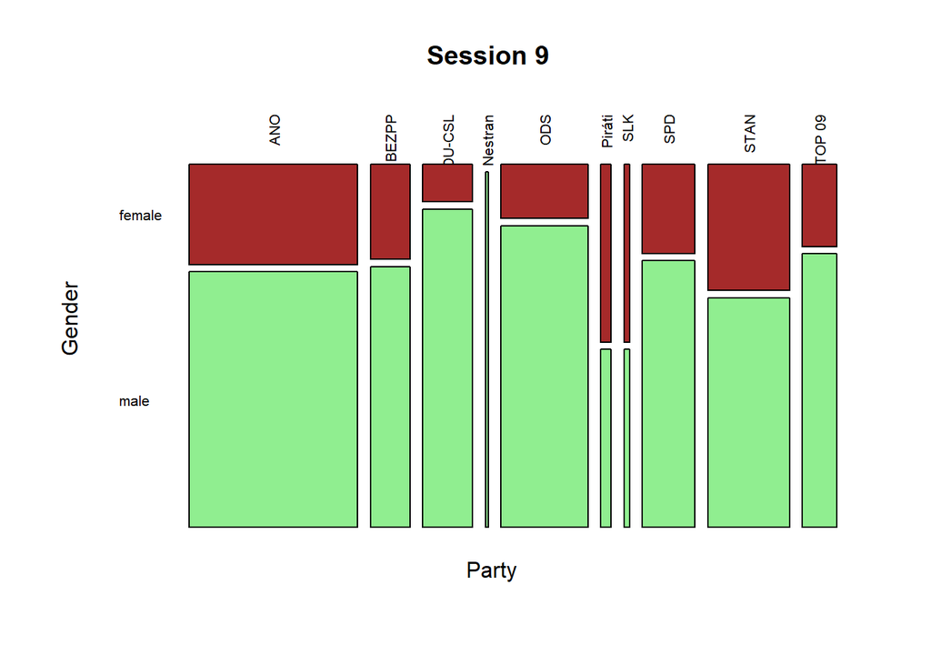

```r
# Isolate session 9
session_9 <- joint_df |>
  filter(session > 8)

# Plot party and sex
plot(
  table(
    session_9$party, session_9$sex),
  main = "Session 9 ",
  xlab = "Party",
  ylab = "Gender",
     col = c("brown", "lightgreen"), las = 2)
```

I choose to compare the gender distribution across parties between session 1 and session 9. I chose these two sessions because they are the furthest in time between each other, hence, the comparison is most likely to be relevant.

My findings show that the gender distribution changed from a session to another, coherently with the growing trend of women in politics.

Expectedly so, the parties in session 1 and the ones in session 9 are not the same. Hence, it is not always possible to check each single party performance gender quota wise. Nevertheless, the party OSA, present in both sessions, shows visible signs of improvement and a bigger share of female legislators.

On a side note, it is interesting to notice that there is less parties compared to session 1. This might be due to party system realignment, a situation where, over time, a large number of political parties in a given political system coalesce into fewer, larger parties.